# Tarea 5

Shanthal Chavarría

9/1/2020

```r
library(knitr)
library(rmdformats)
library(ggplot2)
library(GGally)
library(factoextra)
library(FactoMineR)


knitr::opts_chunk$set(echo = TRUE)

options(max.print="75")

opts_chunk$set(echo=TRUE,
                 cache=FALSE,
               prompt=FALSE,
               tidy=TRUE,
               comment=NA,
               message=FALSE,
               warning=FALSE)
```

# Pregunta 1

En este ejerciciousaremos la tabla de datos EjemploAlgoritmosRecomendación.csv, la cual contiene los promedios de evaluación de 100 personas que adquirieron los mismos productos o muy similares en la tienda AMAZON. La idea consiste en recomendar a un cliente los productos que ha comprado otra persona que pertenece al mismo clúster.

```r
library(readr)

EjemploAlgoritmosRecomendacion <- read.table("DatosTarea/EjemploAlgoritmosRecomendacion.csv", sep = ";", dec = ",", row.names = 1, header = T)
```

## a) Ejecute un Clustering Jerárquico con la distancia euclídea y la agregación del Salto Máximo, Salto Mínimo, Promedio y Ward. Guarde la tabla de datos en el archivo AlgoritmosRecomendación2.csv con el clúster al que pertenece cada individuo para el caso de la agregación de Ward usando 2 clústeres.

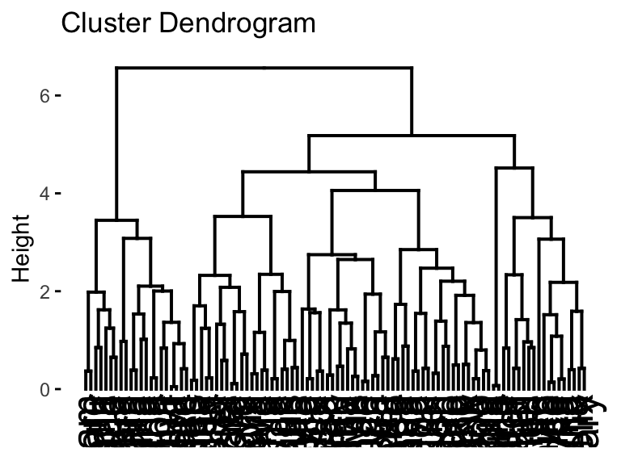

```r
#distancia euclidea



#salto máximo
modelo <- hclust(dist(EjemploAlgoritmosRecomendacion, method = "euclidean"), method = "complete")

fviz_dend(modelo, cex = 1.3)
```

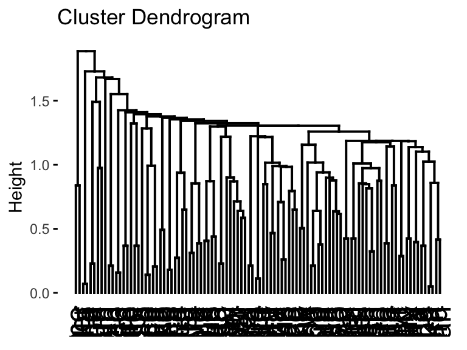

```r
#salto mínimo
modelo <- hclust(dist(EjemploAlgoritmosRecomendacion, method = "euclidean"), method = "single")

fviz_dend(modelo, cex = 1.3)
```

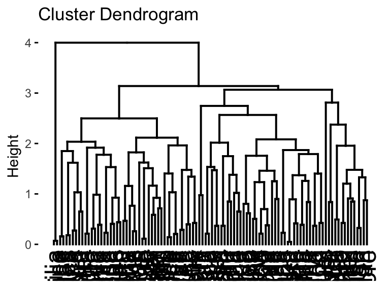

```r
#salto promedio

modelo <- hclust(dist(EjemploAlgoritmosRecomendacion, method = "euclidean"), method = "average")

fviz_dend(modelo, cex = 1.3)
```

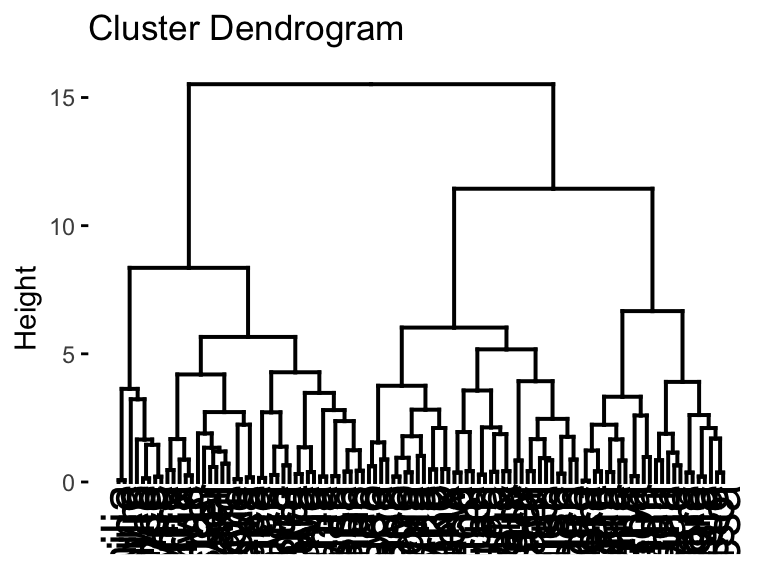

```r
#ward
modelo <- hclust(dist(EjemploAlgoritmosRecomendacion, method = "euclidean"), method = "ward.D2")

fviz_dend(modelo, cex = 1.3)
```

```r
#tabla de datos
Grupos <- cutree(modelo, k = 2)

NDatos <- cbind(EjemploAlgoritmosRecomendacion, Grupos)

NDatos
```

```
        VelocidadEntrega Precio Durabilidad ImagenProducto ValorEducativo
Adam                2.05   0.30        3.45           2.35            2.4
Anna                0.90   1.50        3.15           3.30            2.5
Bernard             1.70   2.60        2.85           3.00            4.3
Edward              1.35   0.50        3.55           2.95            1.8
Emilia              3.00   0.45        4.80           3.90            3.4
Fabian              0.95   1.65        3.95           2.40            2.6
Philip              2.30   1.20        4.75           3.30            3.5
        ServicioRetorno TamanoPaquete Calidad.Producto NumeroEstrellas Grupos
Adam                2.3          2.60             2.10             1.7      1
Anna                4.0          4.20             2.15             2.8      1
Bernard             2.7          4.10             2.60             3.3      1
Edward              2.3          3.90             1.95             1.7      1
Emilia              4.6          2.25             3.40             4.3      2
Fabian              1.9          4.85             2.20             3.0      1
Philip              4.5          3.80             2.90             3.1      2
 [ reached 'max' / getOption("max.print") -- omitted 93 rows ]
```

```r
#guardo el archivo
write.csv(NDatos,"AlgoritmosRecomendación2.csv")
```

## b) “Corte” el árbol anterior usando 2 clústeres y la agregación de Ward, interprete los resultados usando interpretación usando gráficos de barras (Horizontal-Vertical) y usando gráficos tipo Radar.

[figure not shown]

```r
library(cluster)
library(fmsb)

# Función para encontrar el centroide de cada cluster del profesor Oldemar
centroide <- function(num.cluster, datos, clusters) {
  ind <- (clusters == num.cluster)
  return(colMeans(datos[ind,]))
}

centro.cluster1 <-centroide(1,EjemploAlgoritmosRecomendacion,Grupos)

centro.cluster2 <-centroide(2,EjemploAlgoritmosRecomendacion,Grupos)

centros<-rbind(centro.cluster1,centro.cluster2)

colores <- c('#00429d', '#2e59a8', '#4771b2', '#5d8abd', '#73a2c6', '#8abccf', '#a5d5d8', '#c5eddf', '#ffffe0')

#gráfico de barras

barplot(t(centros),beside=TRUE,legend = colnames(centros), main = "Gráfico de interpretación de Clases", col=colores, cex.names = 0.65 , ylim = c(0,8))
```

En este gráfico de barras se observa que para el primer cluster, las personas dieron calificaciones altas en Durabilidad y Tamaño del Paquete; y callificaciones bajas en Velocidad de Entrega y Precio. El segundo cluster, la personas valoraron más alto la tienda y dieron calificaciones altas en Durabilidad y Velocidad de Entrega en comparación al primer cluster, pero valoraron más bajo el Precio y Tamaño del Paquete.

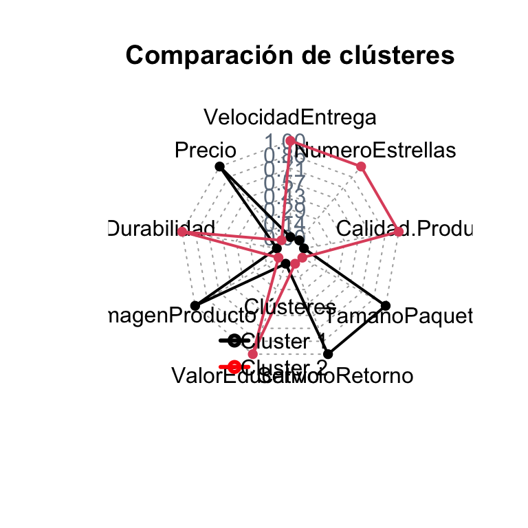

```r
#gráfico tipo radar
centros<-as.data.frame(centros)
maximos<-apply(centros,2,max)
minimos<-apply(centros,2,min)
centros<-rbind(minimos,centros)
centros<-rbind(maximos,centros)

radarchart(as.data.frame(centros),maxmin=TRUE,axistype=4,axislabcol="slategray4",
             centerzero=FALSE,seg=7,
           cglcol="gray67",plty=1,plwd=2,title="Comparación de clústeres")

legend("bottom" ,legend=c("Cluster 1","Cluster 2"),
seg.len=-1.4,title="Clústeres",pch=21,bty="n" ,lwd=3, y.intersp=1, col = c("black","red"), xjust = 10,
                horiz=FALSE)
```

En este gráfico el primer cluster se valoró alto el Tamaño del Paquete, Servicio de Retorno, Imagen del Producto y Precio. Se bajó puntos en Velocidad, Estrellas, Calidad, Valor Educativo y Durabilidad Para el segundo Cluster, se valoró más la Velocidad de Entrega, Número de Estrellas, Calidad del Producto, Durabilidad y Valor Educativo, pero se rebajó en Servicio de Retorno, Precio, Imagen y Tamaño del Paquete

## c) Si se tienen 4 clústeres usando agregación de Ward ¿Qué productos recomendaría a Teresa, a Leo y a Justin?, es decir, ¿los productos que compra cúal otro cliente? Usando distancia euclídea ¿cuál es la mejor recomendación de compra que le podemos hacer a Teresa, a Leo y a Justin?

[figure not shown]

```r
modelo <- hclust(dist(EjemploAlgoritmosRecomendacion, method = "euclidean"),method= "ward.D2")

plot(modelo)

rect.hclust(modelo, k = 4, border = "magenta")
```

Teresa está en el cluster 1, por lo que le podrían gustar los productos de Lydia. Leo en el 2 podría compartir gustos con Jeremiah. Justin en el 3 podría tener preferencias similares a las de Flora.

## d) Construya un clustering jerárquico sobre las componentes principales del ACP.

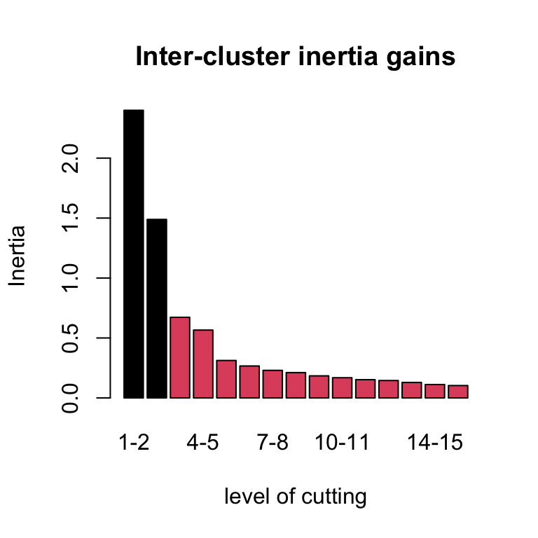

```r
res  <- PCA(EjemploAlgoritmosRecomendacion, scale.unit=TRUE, ncp=5, graph = FALSE)
res.hcpc <- HCPC(res, nb.clust = -1, consol = TRUE, min = 3, max = 3, graph = FALSE)
plot.HCPC(res.hcpc, choice="bar")
```

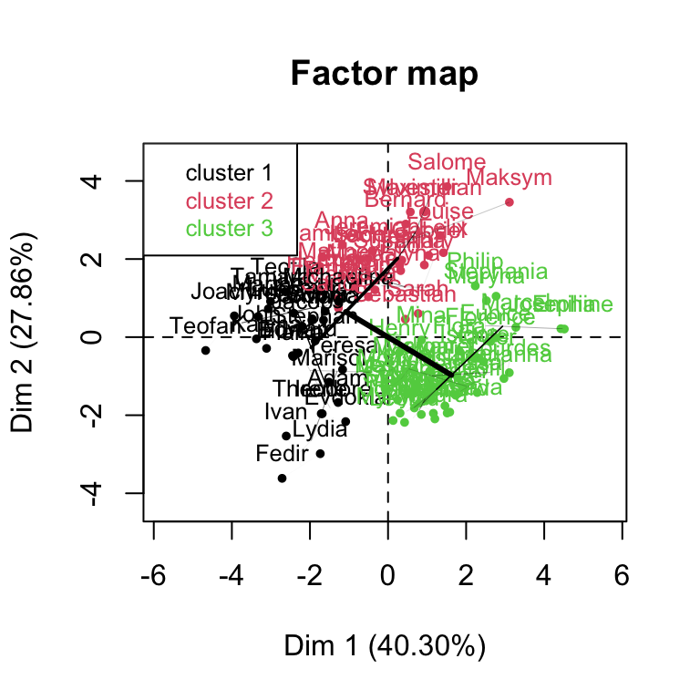

```r
plot.HCPC(res.hcpc, choice="map",select="cos2 0.1")
```

# Pregunta 2

La tabla de datos VotosCongresoUS.csv la cual contiene 16 votos (y=Sí, n=No, NS=No votó) dados por los congresistas de Estados Unidos respecto a 16 temáticas diferentes, además en la primera columna aparece el partido al que pertenecen (Republicano o Demócrata).

## a) Ejecute una clasificación jerárquica sobre esta tabla de datos usando la función daisy ya que los datos son cualitativos. Use métrica euclidean y método complete (deje el resultado en la variable jer). Cargue los datos con la siguiente instrucción:

Datos <- read.csv(“VotosCongresoUS.csv”,header=TRUE, sep=“,”, dec=“.”)

```r
library(cluster)

Datos <- read.csv("DatosTarea/VotosCongresoUS.csv",header=TRUE, sep=",", dec=".", stringsAsFactors = TRUE)

D <- daisy(Datos, metric = "euclidean")
jer <- hclust(D, method = "complete")
```

## b) Luego “corte” el árbol usando 3 clústeres y ejecute el siguiente código:

grupo<-cutree(jer, k = 3) NDatos<-cbind(Datos,grupo) \ \ cluster<-NDatos$grupo sel.cluster1<-match(cluster,c(1),0) Datos.Cluster1<-NDatos[sel.cluster1>0,] dim(Datos.Cluster1) \ \ sel.cluster2<-match(cluster,c(2),0) Datos.Cluster2<-NDatos[sel.cluster2>0,] dim(Datos.Cluster2) \ \ sel.cluster3<-match(cluster,c(3),0) Datos.Cluster3<-NDatos[sel.cluster3>0,] dim(Datos.Cluster3)

```r
grupo<-cutree(jer, k = 3) #corta el arbol en 3 clusters
NDatos<-cbind(Datos,grupo) #crea una nueva tabla igual a la de Datos pero le agrega la columna del cluster al que corresponde

cluster<-NDatos$grupo # se extrae un vector con el cluster de cada fila
sel.cluster1 <- match(cluster,1,0) #vector que tiene 1 en la posición donde había un 1 en cluster y 0 sino
Datos.Cluster1 <-NDatos[sel.cluster1>0,] #Nueva tabla que toma solo las filas del cluster 1 según el índice del vector anterior
dim(Datos.Cluster1) #dimensiones de la tabla anterior
```

```
[1] 232  18
```

```r
sel.cluster2<-match(cluster,2,0) #vector que tiene 2 en la posición donde había un 2 en cluster y 0 sino
Datos.Cluster2<-NDatos[sel.cluster2>0,] #Nueva tabla que toma solo las filas del cluster 2 según el índice del vector anterior
dim(Datos.Cluster2) #dimensiones de la tabla anterior
```

```
[1] 198  18
```

```r
sel.cluster3<-match(cluster,3,0) #vector que tiene 3 en la posición donde había un 2 en cluster y 0 sino
Datos.Cluster3<-NDatos[sel.cluster3>0,] #Nueva tabla que toma solo las filas del cluster 3 según el índice del vector anterior
dim(Datos.Cluster3) #dimensiones de la tabla anterior
```

```
[1]  5 18
```

Explique qué hace el código anterior. Luego ejecute el siguiente código: plot(Datos$Party,col=c(4,6),las=2,main="Party",xlab="Todos los Datos") \n plot(Datos.Cluster1$Party,col=c(4,6),las=2,main=“Party”,xlab=“Cluster-1”) plot(Datos.Cluster2$Party,col=c(4,6),las=2,main="Party",xlab="Cluster-2") \n plot(Datos.Cluster3$Party,col=c(4,6),las=2,main=“party”,xlab=“Cluster-3”)

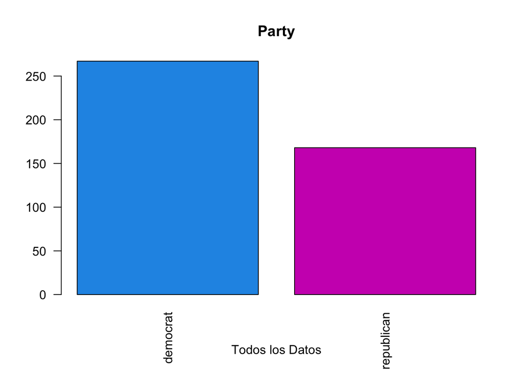

```r
plot(Datos$Party,col=c(4,6),las=2,main="Party",xlab="Todos los Datos")
```

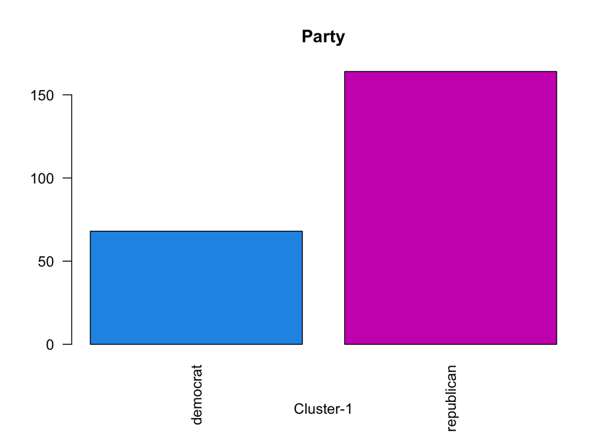

```r
plot(Datos.Cluster1$Party,col=c(4,6),las=2,main="Party",xlab="Cluster-1")
```

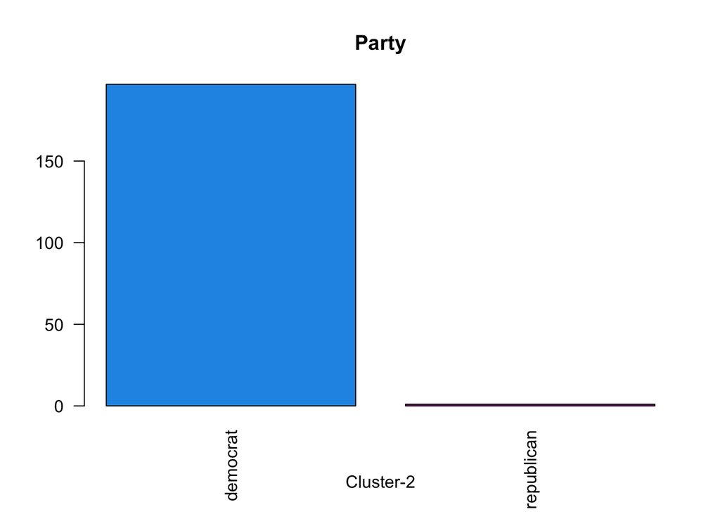

```r
plot(Datos.Cluster2$Party,col=c(4,6),las=2,main="Party",xlab="Cluster-2")
```

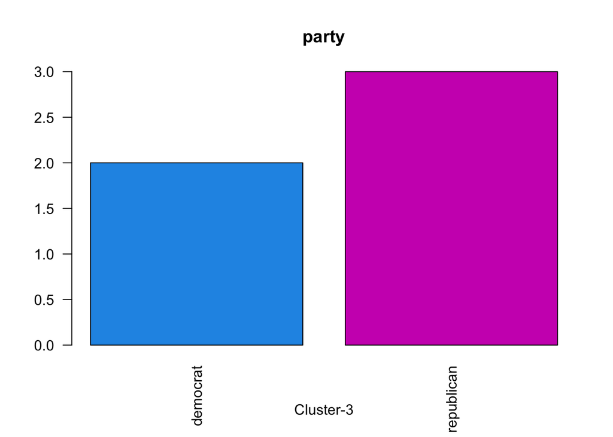

```r
plot(Datos.Cluster3$Party,col=c(4,6),las=2,main="party",xlab="Cluster-3")
```

# Pregunta 3

Realice un análisis similar al del ejercicio anterior con la tabla de datos CompraBicicletas.csv.

```r
Datos1 <- read.csv("DatosTarea/CompraBicicletas.csv",header=TRUE, sep=";", dec=".", stringsAsFactors = TRUE)

D1 <- daisy(Datos1, metric = "euclidean")
jer1 <- hclust(D1, method = "complete")
```

```r
grupo1<-cutree(jer1, k = 3)
NDatos1<-cbind(Datos1,grupo1)

cluster1<-NDatos1$grupo1
sel.cluster1<-match(cluster1,c(1),0)
Datos.Cluster1<-NDatos1[sel.cluster1>0,]
dim(Datos.Cluster1)
```

```
[1] 518  14
```

```r
sel.cluster2<-match(cluster1,c(2),0)
Datos.Cluster2<-NDatos1[sel.cluster2>0,]
dim(Datos.Cluster2)
```

```
[1] 123  14
```

```r
sel.cluster3<-match(cluster1,c(3),0)
Datos.Cluster3<-NDatos1[sel.cluster3>0,]
dim(Datos.Cluster3)
```

```
[1] 359  14
```

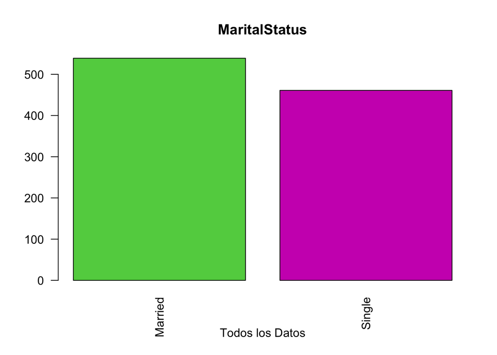

```r
plot(Datos1$MaritalStatus,col=c(3,6),las=2,main="MaritalStatus",xlab="Todos los Datos")
```

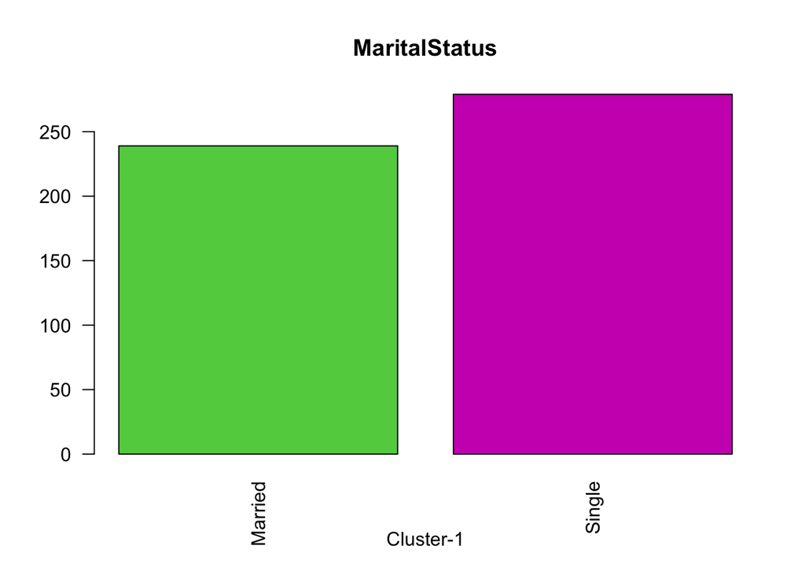

```r
plot(Datos.Cluster1$MaritalStatus,col=c(3,6),las=2,main="MaritalStatus",xlab="Cluster-1")
```

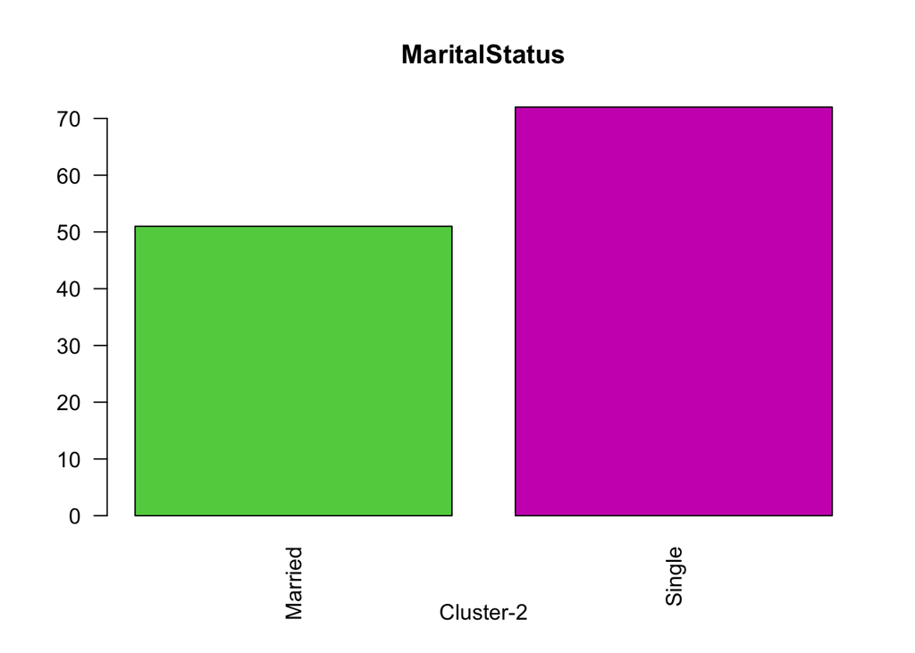

```r
plot(Datos.Cluster2$MaritalStatus,col=c(3,6),las=2,main="MaritalStatus",xlab="Cluster-2")
```

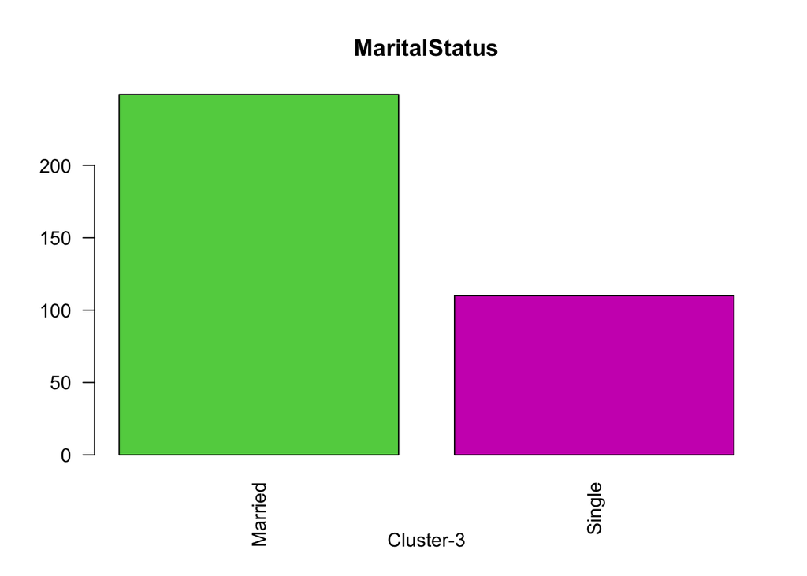

```r
plot(Datos.Cluster3$MaritalStatus,col=c(3,6),las=2,main="MaritalStatus",xlab="Cluster-3")
```

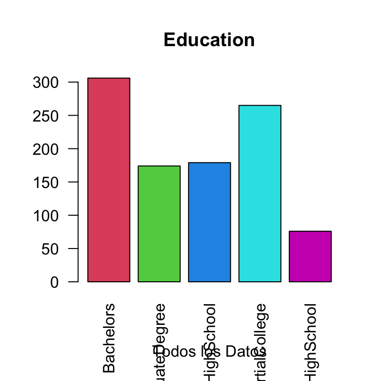

```r
plot(Datos1$Education ,col=c(2,3,4,5,6),las=2,main="Education",xlab="Todos los Datos")
```

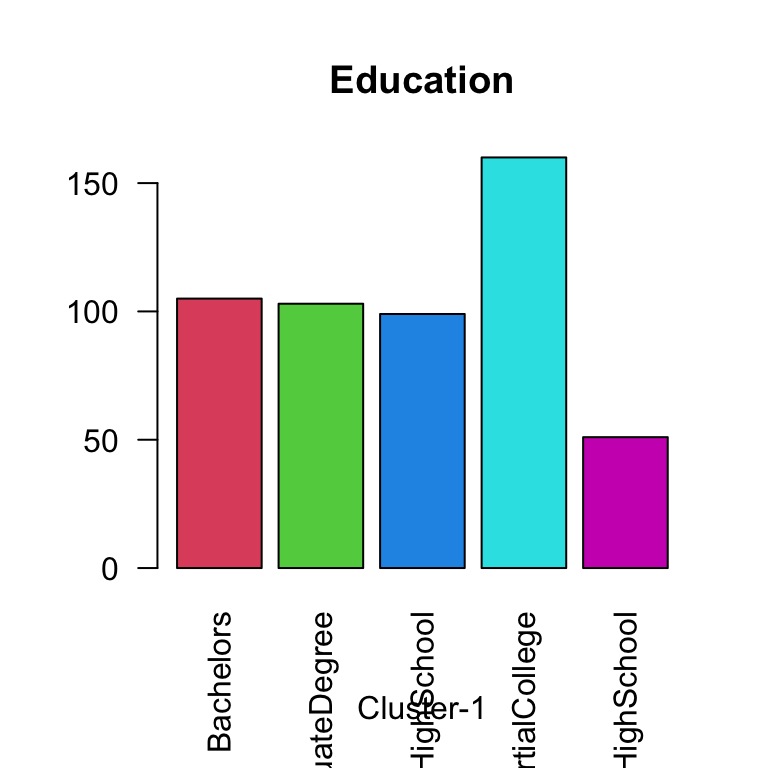

```r
plot(Datos.Cluster1$Education,col=c(2,3,4,5,6),las=2,main="Education",xlab="Cluster-1")
```

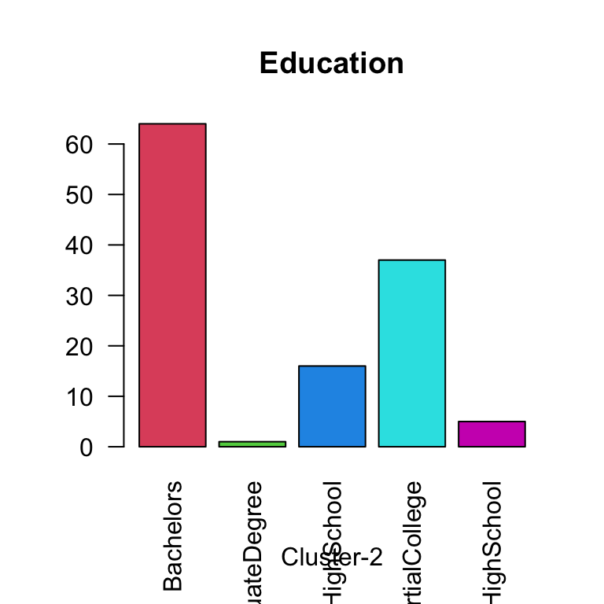

```r
plot(Datos.Cluster2$Education,col=c(2,3,4,5,6),las=2,main="Education",xlab="Cluster-2")
```

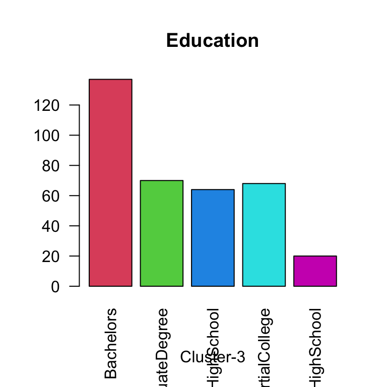

```r
plot(Datos.Cluster3$Education,col=c(2,3,4,5,6),las=2,main="Education",xlab="Cluster-3")
```

# Pregunta 4

Dada la siguiente matriz de disimilitudes entre cuatro individuos A1, A2, A3 y A4, construya “a mano” una Jerarquía Binaria usando la agregación del Salto Máximo y del Promedio, dibuje el dendograma en ambos casos:

$$\begin{pmatrix}
0 & & & \\
5 & 0 & & \\
2 & 1 & 0 & \\
3 & 7 & 6 & 0
\end{pmatrix}$$

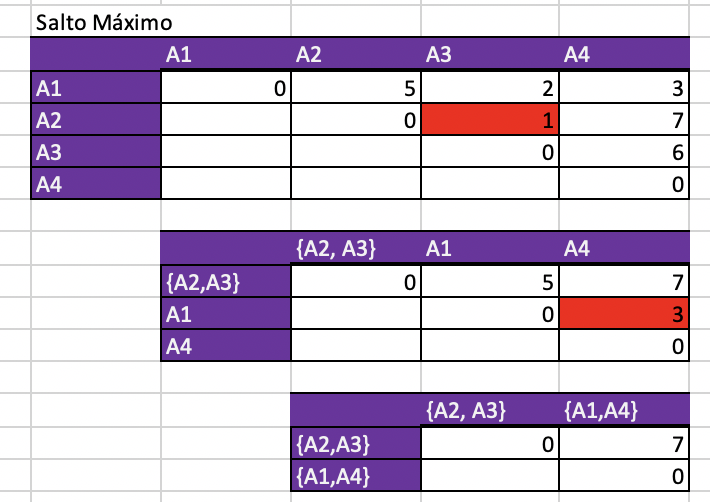

```r
knitr::include_graphics("Captura de Pantalla 2020-09-08 a la(s) 14.17.36.png")
```

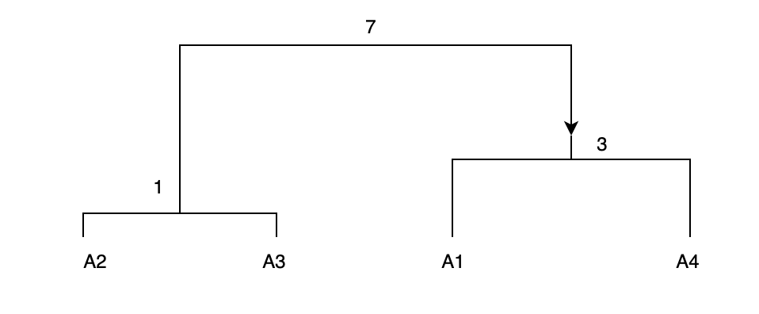

```r
knitr::include_graphics("Captura de Pantalla 2020-09-08 a la(s) 14.14.25.png")
```

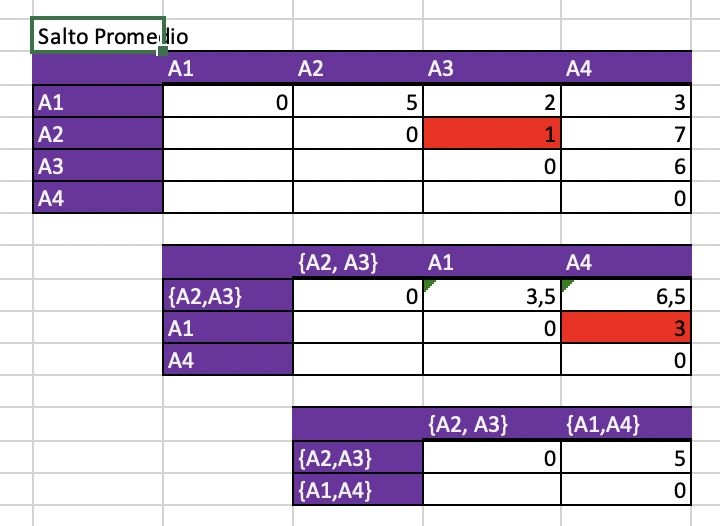

```r
knitr::include_graphics("Captura de Pantalla 2020-09-08 a la(s) 14.17.45.png")
```

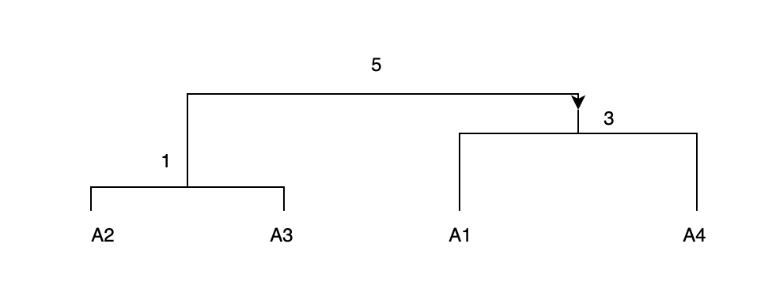

```r
knitr::include_graphics("Captura de Pantalla 2020-09-08 a la(s) 14.13.03.png")
```

Verifique los resultados con hclust.

```r
matriz <- matrix(c(0,5,2,3,5,0,1,7,2,1,0,6,3,7,6,0), nrow=4,ncol=4,"byrow"="true")

matriz
```

```
     [,1] [,2] [,3] [,4]
[1,]    0    5    2    3
[2,]    5    0    1    7
[3,]    2    1    0    6
[4,]    3    7    6    0
```

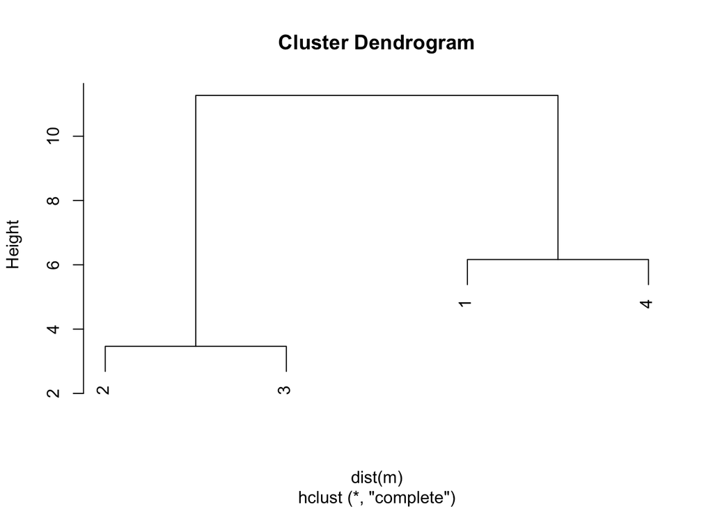

```r
m <- as.data.frame(matriz)
maximo = hclust(dist(m),method = "complete")
plot(maximo)
```

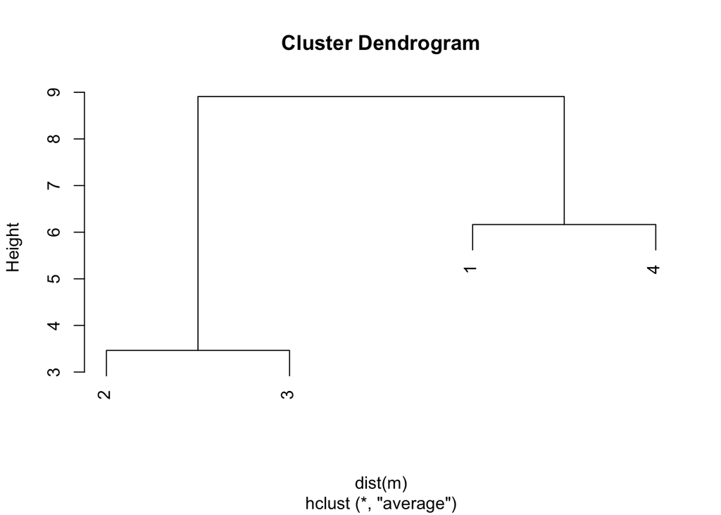

```r
avg = hclust(dist(m),method = "average")
plot(avg)
```